# Práctico 2 Análisis exploratorio y el primer anova

25/03, 2019

## Actividad 1 Educación en Chile

- Pueden encontrar la base de datos original en [Data Chile](https://es.datachile.io/geo/chile#education)
- Trataremos de determinar si existen brechas en la Eduacación Chilena por tipo de institución
- Para ello, primero trabajaremos realizando análisis exploratorios
- Gráficos
- Tablas resumen
- En la próxima tabla veremos la versión cruda de los datos
- Lo primero que deben hacer es generar una tabla resumen usando el tidyverse (group_by, summarize)
- Recuerden: **mean()** promedio; **sd()** desviacion estándar, **n()** número de muestras

## Educación en Chile

```r
EducacionChile <- read_csv("EducacionChile.csv")
```

Datos PSU Chile

| ID.Region | Region | ID.Comuna | Comuna | ID.Administration | Administration | Average.PSU | Average.NEM | Number.of.records |
| --- | --- | --- | --- | --- | --- | --- | --- | --- |
| 1 | Tarapacá | 5 | Alto Hospicio | 1 | Municipal | 459.80 | 5.55 | 76 |
| 1 | Tarapacá | 5 | Alto Hospicio | 2 | Particular Subvencionado | 455.55 | 5.55 | 1289 |
| 1 | Tarapacá | 58 | Colchane | 1 | Municipal | 370.17 | 5.49 | 3 |
| 1 | Tarapacá | 108 | Huara | 1 | Municipal | 378.23 | 5.62 | 15 |
| 1 | Tarapacá | 113 | Iquique | 1 | Municipal | 445.32 | 5.56 | 877 |
| 1 | Tarapacá | 113 | Iquique | 2 | Particular Subvencionado | 514.79 | 5.68 | 2568 |
| 1 | Tarapacá | 113 | Iquique | 3 | Particular Pagado | 580.56 | 5.99 | 125 |
| 1 | Tarapacá | 113 | Iquique | 4 | Corporación de Administración Delegada | 432.49 | 5.37 | 75 |
| 1 | Tarapacá | 217 | Pica | 1 | Municipal | 443.55 | 5.66 | 24 |
| 1 | Tarapacá | 226 | Pozo Almonte | 1 | Municipal | 410.49 | 5.62 | 211 |
| 1 | Tarapacá | 226 | Pozo Almonte | 2 | Particular Subvencionado | 373.00 | 4.90 | 1 |
| 2 | Antofagasta | 9 | Antofagasta | 1 | Municipal | 446.05 | 5.58 | 2365 |
| 2 | Antofagasta | 9 | Antofagasta | 2 | Particular Subvencionado | 520.52 | 5.61 | 2220 |
| 2 | Antofagasta | 9 | Antofagasta | 3 | Particular Pagado | 560.57 | 5.72 | 972 |
| 2 | Antofagasta | 19 | Calama | 1 | Municipal | 471.04 | 5.44 | 1734 |
| 2 | Antofagasta | 19 | Calama | 2 | Particular Subvencionado | 523.33 | 5.62 | 746 |
| 2 | Antofagasta | 19 | Calama | 3 | Particular Pagado | 550.82 | 5.75 | 484 |
| 2 | Antofagasta | 165 | María Elena | 1 | Municipal | 457.38 | 5.89 | 64 |
| 2 | Antofagasta | 170 | Mejillones | 1 | Municipal | 427.72 | 5.87 | 95 |
| 2 | Antofagasta | 297 | San Pedro De Atacama | 1 | Municipal | 460.67 | 5.57 | 32 |
| 2 | Antofagasta | 313 | Taltal | 1 | Municipal | 440.32 | 5.98 | 155 |
| 2 | Antofagasta | 321 | Tocopilla | 1 | Municipal | 392.14 | 5.48 | 167 |
| 2 | Antofagasta | 321 | Tocopilla | 2 | Particular Subvencionado | 508.28 | 5.65 | 105 |
| 3 | Atacama | 4 | Alto Del Carmen | 1 | Municipal | 447.98 | 5.58 | 23 |
| 3 | Atacama | 21 | Caldera | 1 | Municipal | 400.19 | 5.37 | 71 |
| 3 | Atacama | 21 | Caldera | 2 | Particular Subvencionado | 474.61 | 5.55 | 110 |
| 3 | Atacama | 39 | Chañaral | 1 | Municipal | 455.20 | 5.79 | 127 |
| 3 | Atacama | 39 | Chañaral | 2 | Particular Subvencionado | 449.43 | 5.81 | 18 |
| 3 | Atacama | 68 | Copiapó | 1 | Municipal | 449.29 | 5.38 | 986 |
| 3 | Atacama | 68 | Copiapó | 2 | Particular Subvencionado | 519.58 | 5.52 | 1296 |

[output cut: 641 more lines]

## Resumiendo los datos de Chile

```r
EducacionChileResumen <- group_by(EducacionChile, Administration) %>%
    summarise(PromedioPSU = mean(Average.PSU), SD.PSU = sd(Average.PSU),
        N = n())
```

Promedios totales PSU

| Administration | PromedioPSU | SD.PSU | N |
| --- | --- | --- | --- |
| Corporación de Administración Delegada | 452.23 | 21.74 | 39 |
| Municipal | 445.00 | 32.97 | 320 |
| Particular Pagado | 599.99 | 34.83 | 78 |
| Particular Subvencionado | 483.93 | 41.41 | 234 |

¿Qué podemos decir de estos datos?

## Visualización de datos con ggplot2 (tidyverse)

- Función para graficar ggplot
- Usaremos el simbolo **+** como usabamos el pipeline
- Aprenderemos dos tipos de gráficos
- Box plots
- jitter plots

## Visualización de datos con ggplot2 (tidyverse)

- Primero usamos la función ggplot para determinar la base de datos y variables, las variables siempre van dentro de la función aes

```r
ggplot(MiBaseDeDatos, aes(x = VariableX, y = VariableY))
```

- Luego agregamos el tipo de gráfico que queremos para nuestra figura usando el **+** como pipeline

```r
ggplot(MiBaseDeDatos, aes(x = VariableX, y = VariableY)) +
    geom_boxplot()
```

## Visualización de datos con ggplot2

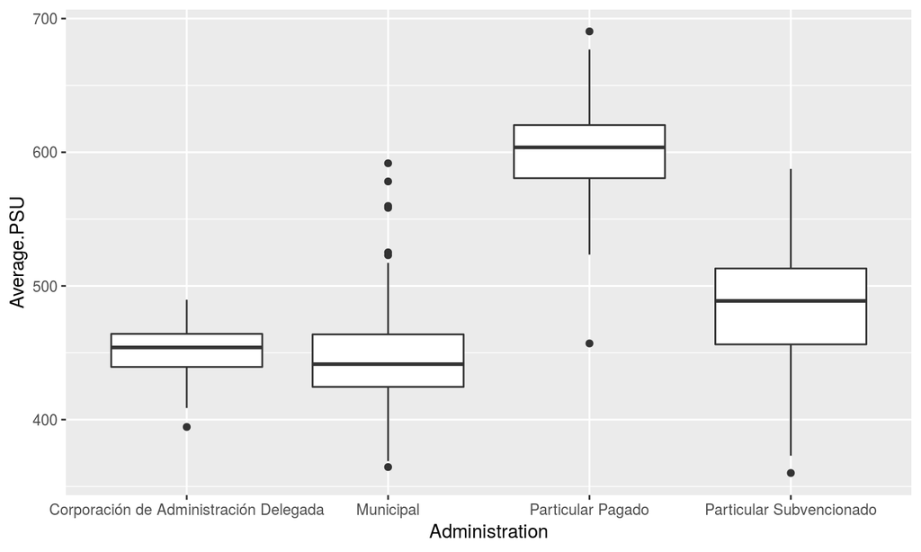

```r
ggplot(EducacionChile, aes(x = Administration, y = Average.PSU)) +
    geom_boxplot()
```

## Visualización de datos con ggplot2

- Box plot
  - Mediana (linea grueza)
  - Caja (Cuantiles 25% y 75%)
  - Bigotes (intervalo de confianza del 95%)
  - Puntos Outlayers
- ¿Qué nos dice esto de los datos?

## Visualización de datos con ggplot2

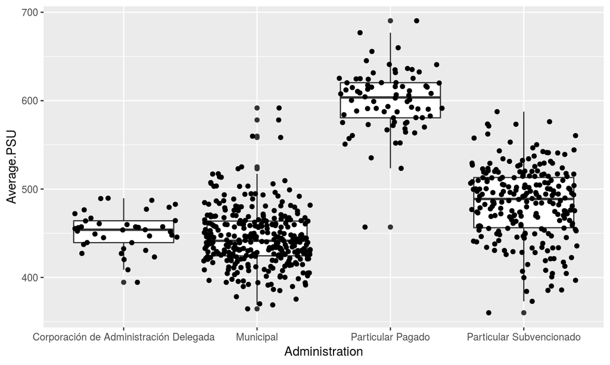

```r
ggplot(EducacionChile, aes(x = Administration, y = Average.PSU)) +
    geom_boxplot() + geom_jitter()
```

## Visualización de datos con ggplot2

- Jitter plot
  - agrega puntos de cada observación

## Actividad 2 Captación de CO2 en plantas

Utilizaremos base de datos CO2 que esta en R

- **Plant**: Identidad de cada planta
- **Type**: Variedad de la planta (subespecie Quebec o Mississippi)
- **Treatment**: Tratamiento de la planta, algunas fueron enfriadas la noche anterior (Chilled)
- **conc**: Concentración ambiental de \(CO_2\)
- **Uptake**: Captación de \(CO_2\) para cada planta en cada día

## Captación de CO2 en plantas

¿Hay diferencias entre la captación de \(CO_2\) en plantas tratadas y no tratadas?

- Genere tablas resumenes que le permitan explorar esta pregunta
  - ¿Existen variables que puedan confundir el resultado? ¿como trataría los datos para lidiar con esto?
- Generar gráficos exploratorios para contestar esta pregunta

## Captación de CO2 en plantas (Tablas)

```r
data("CO2")
Co2 <- CO2 %>% group_by(Treatment) %>% summarise(PromedioCO2 = mean(uptake),
    SD.CO2 = sd(uptake), N = n())
```

| Treatment | PromedioCO2 | SD.CO2 | N |
| --- | --- | --- | --- |
| nonchilled | 30.64 | 9.70 | 42 |
| chilled | 23.78 | 10.88 | 42 |

## Captación de CO2 en plantas (Tablas)

```r
Co2Real <- CO2 %>% group_by(Plant, Type, Treatment) %>%
    summarise(PromedioCO2 = mean(uptake))
```

| Plant | Type | Treatment | PromedioCO2 |
| --- | --- | --- | --- |
| Qn1 | Quebec | nonchilled | 33.23 |
| Qn2 | Quebec | nonchilled | 35.16 |
| Qn3 | Quebec | nonchilled | 37.61 |
| Qc1 | Quebec | chilled | 29.97 |
| Qc3 | Quebec | chilled | 32.59 |
| Qc2 | Quebec | chilled | 32.70 |
| Mn3 | Mississippi | nonchilled | 24.11 |
| Mn2 | Mississippi | nonchilled | 27.34 |
| Mn1 | Mississippi | nonchilled | 26.40 |
| Mc2 | Mississippi | chilled | 12.14 |
| Mc3 | Mississippi | chilled | 17.30 |
| Mc1 | Mississippi | chilled | 18.00 |

## Captación de CO2 en plantas (Tablas)

```r
Co2Resumen <- Co2Real %>% group_by(Treatment) %>% summarise(SD.CO2 = sd(PromedioCO2),
    PromedioCO2 = mean(PromedioCO2), N = n())
```

| Treatment | SD.CO2 | PromedioCO2 | N |
| --- | --- | --- | --- |
| nonchilled | 5.43 | 30.64 | 6 |
| chilled | 9.01 | 23.78 | 6 |

## Captación de CO2 en plantas (Tablas)

```r
Co2Resumen <- Co2Real %>% group_by(Treatment, Type) %>%
    summarise(SD.CO2 = sd(PromedioCO2), PromedioCO2 = mean(PromedioCO2),
        N = n())
```

| Treatment | Type | SD.CO2 | PromedioCO2 | N |
| --- | --- | --- | --- | --- |
| nonchilled | Quebec | 2.20 | 35.33 | 3 |
| nonchilled | Mississippi | 1.66 | 25.95 | 3 |
| chilled | Quebec | 1.54 | 31.75 | 3 |
| chilled | Mississippi | 3.20 | 15.81 | 3 |

## Captación de CO2 en plantas (Gráficos)

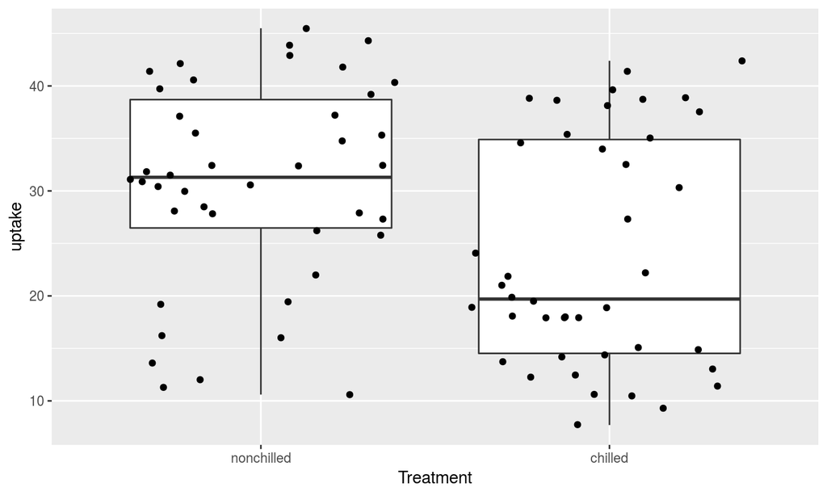

```r
ggplot(CO2, aes(x = Treatment, y = uptake)) + geom_boxplot() +
    geom_jitter()
```

## Captación de CO2 en plantas (Gráficos)

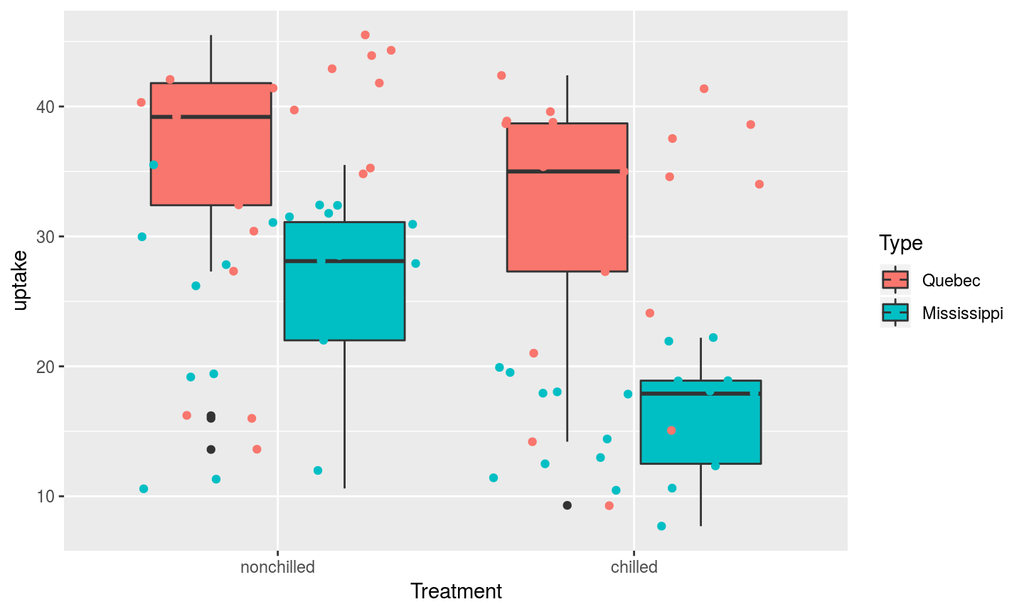

```r
ggplot(CO2, aes(x = Treatment, y = uptake)) + geom_boxplot(aes(fill = Type)) +
    geom_jitter(aes(color = Type))
```

## Captación de CO2 en plantas (Gráficos)

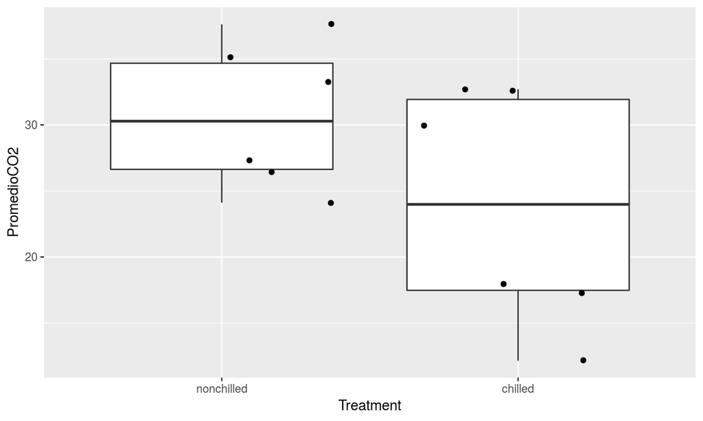

```r
ggplot(Co2Real, aes(x = Treatment, y = PromedioCO2)) +
    geom_boxplot() + geom_jitter()
```

## Captación de CO2 en plantas (Gráficos)

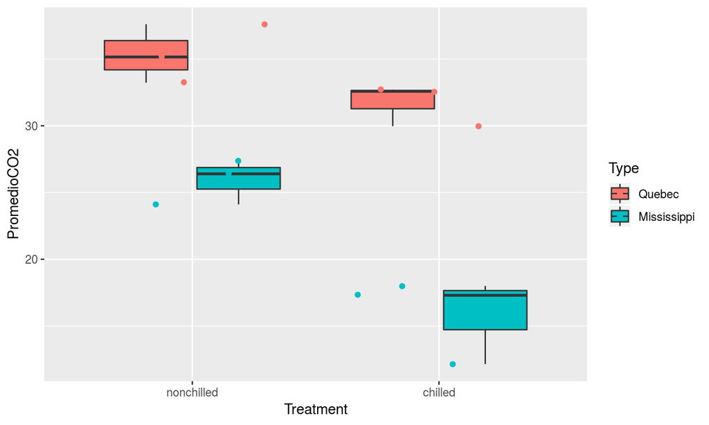

```r
ggplot(Co2Real, aes(x = Treatment, y = PromedioCO2)) +
    geom_boxplot(aes(fill = Type)) + geom_jitter(aes(color = Type))
```

## Ahora un anova pero antes…

Entendamos como funciona usando un [simulador de anova](http://www.derek-corcoran-barrios.com/AyduantiaStats/_book/Explorando.html#antes-de-empezar-a-entender-el-anova)

[interactive chart not shown]

## Captación de CO2 en plantas (Mi primer ANOVA)

- Funcion *aov(y ~ x, data = MisDatos)*
- Esto se debe leer como y explicado por x. (siempre leer *~* explicado por)

```r
Primer.Anova <- aov(PromedioCO2 ~ Treatment, data = Co2Real)
summary(Primer.Anova)
```

```
##             Df Sum Sq Mean Sq F value Pr(>F)
## Treatment    1  141.2  141.16   2.551  0.141
## Residuals   10  553.4   55.34
```

## Captación de CO2 en plantas (Mi primer ANOVA)

```r
Primer.Anova <- aov(PromedioCO2 ~ Treatment + Type,
    data = Co2Real)
summary(Primer.Anova)
```

```
##             Df Sum Sq Mean Sq F value   Pr(>F)
## Treatment    1  141.2   141.2   17.49  0.00237 **
## Type         1  480.8   480.8   59.56 2.95e-05 ***
## Residuals    9   72.7     8.1
## ---
## Signif. codes:  0 '***' 0.001 '**' 0.01 '*' 0.05 '.' 0.1 ' ' 1
```